# ENSEMBLE LEARNING PROJECT - SOLUTION

```python
recall, precision, f1score, rocAucscore = getPerfParams(abcl, prediction_ABC1)

tempResultsDf = pd.DataFrame({'Method': [ml_model_type], 'Parameter':model_type_param, 'Training score': train_score, 'Accuracy': test_score, 'Recall':recall, 'Precision':precision, 'F1_Score':f1score, 'ROC_AUC Score':rocAucscore})
resultsDf = pd.concat([resultsDf, tempResultsDf])
resultsDf
```

|  | Method | Parameter | Training score | Accuracy | Recall | Precision | F1_Score | ROC_AUC Score |
| --- | --- | --- | --- | --- | --- | --- | --- | --- |
| 0 | Logistic Regression | liblinear-penalty=l2 | 0.900812 | 0.898776 | 0.325407 | 0.638037 | 0.430999 | 0.650377 |
| 0 | Logistic Regression | liblinear-penalty=l1 | 0.900654 | 0.898850 | 0.326658 | 0.638142 | 0.432119 | 0.650961 |
| 0 | Decision Tree | gini max_depth=5 | 0.906342 | 0.899219 | 0.333542 | 0.638323 | 0.438142 | 0.654152 |
| 0 | Decision Tree | entropy max_depth=5 | 0.904130 | 0.897154 | 0.312891 | 0.627353 | 0.417537 | 0.644035 |
| 0 | Bagging Classifier | estimators=10 | 0.980156 | 0.898113 | 0.405507 | 0.600000 | 0.483943 | 0.684702 |
| 0 | Bagging Classifier | estimators=30 | 0.991848 | 0.902094 | 0.444305 | 0.617391 | 0.516739 | 0.703767 |
| 0 | Bagging Classifier | estimators=50 | 0.993080 | 0.901209 | 0.451815 | 0.608769 | 0.518678 | 0.706519 |
| 0 | RandomForest Classifier | estimators=10 | 0.992290 | 0.897007 | 0.346683 | 0.610805 | 0.442315 | 0.658592 |
| 0 | RandomForest Classifier | estimators=30 | 0.998989 | 0.903716 | 0.387359 | 0.654334 | 0.486635 | 0.680016 |
| 0 | RandomForest Classifier | estimators=50 | 0.999779 | 0.902241 | 0.375469 | 0.646552 | 0.475059 | 0.674029 |
| 0 | AdaBoost Classifier | estimators=10 | 0.885424 | 0.884547 | 0.025657 | 0.820000 | 0.049757 | 0.512452 |

INSIGHT: Recall, Precision, F1 Score and ROC_AUC Score showed poor results - we will need to examine this phenomenon further, with increase in number of estimators - however, if this trend continue - it might just show certain limitation of AdaBoost Classifier.

```python
#Step 2 - AdaBoost Classifier, using 30 estimators
abc2 = AdaBoostClassifier(n_estimators = 30, learning_rate=0.1, random_state=22)
abc2 = abc2.fit(X_train, y_train)

model_type_param = 'estimators=30'

train_score = abc2.score(X_train, y_train)
test_score = abc2.score(X_test, y_test)

print('Training data score: ', train_score)
print('Testing data score: ', test_score)

prediction_ABC2 = abc2.predict(X_test)

acc_ABC = accuracy_score(y_test, prediction_ABC2)
print('Model Accuracy: ', acc_ABC)
```

```
Training data score:  0.8866559231522735
Testing data score:  0.8856531996461221
Model Accuracy:  0.8856531996461221
```

```python
recall, precision, f1score, rocAucscore = getPerfParams(abc2, prediction_ABC2)

tempResultsDf = pd.DataFrame({'Method': [ml_model_type], 'Parameter':model_type_param, 'Training score': train_score, 'Accuracy': test_score, 'Recall':recall, 'Precision':precision, 'F1_Score':f1score, 'ROC_AUC Score':rocAucscore})
resultsDf = pd.concat([resultsDf, tempResultsDf])
resultsDf
```

|  | Method | Parameter | Training score | Accuracy | Recall | Precision | F1_Score | ROC_AUC Score |
| --- | --- | --- | --- | --- | --- | --- | --- | --- |
| 0 | Logistic Regression | liblinear-penalty=l2 | 0.900812 | 0.898776 | 0.325407 | 0.638037 | 0.430999 | 0.650377 |
| 0 | Logistic Regression | liblinear-penalty=l1 | 0.900654 | 0.898850 | 0.326658 | 0.638142 | 0.432119 | 0.650961 |
| 0 | Decision Tree | gini max_depth=5 | 0.906342 | 0.899219 | 0.333542 | 0.638323 | 0.438142 | 0.654152 |
| 0 | Decision Tree | entropy max_depth=5 | 0.904130 | 0.897154 | 0.312891 | 0.627353 | 0.417537 | 0.644035 |
| 0 | Bagging Classifier | estimators=10 | 0.980156 | 0.898113 | 0.405507 | 0.600000 | 0.483943 | 0.684702 |
| 0 | Bagging Classifier | estimators=30 | 0.991848 | 0.902094 | 0.444305 | 0.617391 | 0.516739 | 0.703767 |
| 0 | Bagging Classifier | estimators=50 | 0.993080 | 0.901209 | 0.451815 | 0.608769 | 0.518678 | 0.706519 |
| 0 | RandomForest Classifier | estimators=10 | 0.992290 | 0.897007 | 0.346683 | 0.610805 | 0.442315 | 0.658592 |
| 0 | RandomForest Classifier | estimators=30 | 0.998989 | 0.903716 | 0.387359 | 0.654334 | 0.486635 | 0.680016 |
| 0 | RandomForest Classifier | estimators=50 | 0.999779 | 0.902241 | 0.375469 | 0.646552 | 0.475059 | 0.674029 |
| 0 | AdaBoost Classifier | estimators=10 | 0.885424 | 0.884547 | 0.025657 | 0.820000 | 0.049757 | 0.512452 |
| 0 | AdaBoost Classifier | estimators=30 | 0.886656 | 0.885653 | 0.039424 | 0.797468 | 0.075134 | 0.519044 |

```python
#Step 3 - AdaBoost Classifier, using 50 estimators
abc3 = AdaBoostClassifier(n_estimators = 50, learning_rate=0.1, random_state=22)
abc3 = abc3.fit(X_train, y_train)

model_type_param = 'estimators=50'

train_score = abc3.score(X_train, y_train)
test_score = abc3.score(X_test, y_test)

print('Training data score: ', train_score)
print('Testing data score: ', test_score)

prediction_ABC3 = abc3.predict(X_test)

acc_ABC = accuracy_score(y_test, prediction_ABC3)
print('Model Accuracy: ', acc_ABC)
```

```
Training data score:  0.8897841817549846
Testing data score:  0.8883072839870245
Model Accuracy:  0.8883072839870245
```

```python
recall, precision, f1score, rocAucscore = getPerfParams(abc3, prediction_ABC3)

tempResultsDf = pd.DataFrame({'Method': [ml_model_type], 'Parameter':model_type_param, 'Training score': train_score, 'Accuracy': test_score, 'Recall':recall, 'Precision':precision, 'F1_Score':f1score, 'ROC_AUC Score':rocAucscore})
resultsDf = pd.concat([resultsDf, tempResultsDf])
resultsDf
```

|  | Method | Parameter | Training score | Accuracy | Recall | Precision | F1_Score | ROC_AUC Score |
| --- | --- | --- | --- | --- | --- | --- | --- | --- |
| 0 | Logistic Regression | liblinear-penalty=l2 | 0.900812 | 0.898776 | 0.325407 | 0.638037 | 0.430999 | 0.650377 |
| 0 | Logistic Regression | liblinear-penalty=l1 | 0.900654 | 0.898850 | 0.326658 | 0.638142 | 0.432119 | 0.650961 |
| 0 | Decision Tree | gini max_depth=5 | 0.906342 | 0.899219 | 0.333542 | 0.638323 | 0.438142 | 0.654152 |
| 0 | Decision Tree | entropy max_depth=5 | 0.904130 | 0.897154 | 0.312891 | 0.627353 | 0.417537 | 0.644035 |
| 0 | Bagging Classifier | estimators=10 | 0.980156 | 0.898113 | 0.405507 | 0.600000 | 0.483943 | 0.684702 |
| 0 | Bagging Classifier | estimators=30 | 0.991848 | 0.902094 | 0.444305 | 0.617391 | 0.516739 | 0.703767 |
| 0 | Bagging Classifier | estimators=50 | 0.993080 | 0.901209 | 0.451815 | 0.608769 | 0.518678 | 0.706519 |
| 0 | RandomForest Classifier | estimators=10 | 0.992290 | 0.897007 | 0.346683 | 0.610805 | 0.442315 | 0.658592 |
| 0 | RandomForest Classifier | estimators=30 | 0.998989 | 0.903716 | 0.387359 | 0.654334 | 0.486635 | 0.680016 |
| 0 | RandomForest Classifier | estimators=50 | 0.999779 | 0.902241 | 0.375469 | 0.646552 | 0.475059 | 0.674029 |
| 0 | AdaBoost Classifier | estimators=10 | 0.885424 | 0.884547 | 0.025657 | 0.820000 | 0.049757 | 0.512452 |
| 0 | AdaBoost Classifier | estimators=30 | 0.886656 | 0.885653 | 0.039424 | 0.797468 | 0.075134 | 0.519044 |
| 0 | AdaBoost Classifier | estimators=50 | 0.889784 | 0.888307 | 0.078223 | 0.748503 | 0.141643 | 0.537356 |

INSIGHT: AdaBoost Classifier with 50 estimators showed improvement in Accuracy, Recall, and F1 Score. Precision however dropped. ROC_AUC also showed improvement. Generally, AdaBoost with equal number of estimators is Third behind Bagging Classifier and RandomForest Classifier.

Possibility exist of marginal improvement in Accuracy, Recall, F1_Score and ROC_AUC Score, however, Precision will continue to drop which is different from other Bagging and Boosting Classifiers used so far in our analysis.

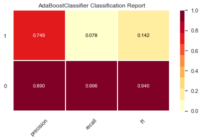

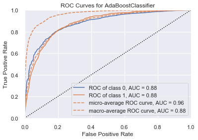

```python
#Fetching visuall Classification Report For our best AdaBoost Classifier -
visualClassifierReport(abc3)
```

```
Training accuracy:  0.8897841817549846

Testing accuracy:  0.8883072839870245

Confusion Matrix
[[  125    42]
 [ 1473 11924]]
```

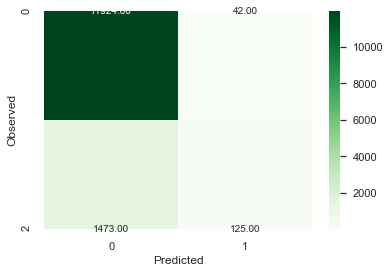

```
None

Recall:  0.07822277847309136

Precision:  0.7485029940119761

F1 Score:  0.141643059490085

ROC_AUC Score:  0.5373564168146837
```

```python
#fetch performance metrics
getModelPerformanceParams(ml_model_type, model_type_param,abc3, prediction_ABC3)
```

```python
#Putting the best AdaBoost Classifier with n_estimator=50 into the final Results Table
trainDataScore,testDataScore,recall, precision, f1score, rocAucScore  = getFinalPerfParams(abc3, prediction_ABC3)

tempfinalResultsDF = pd.DataFrame({'Method':[ml_model_type], 'Parameter':  model_type_param, 'Training score': trainDataScore, 'Accuracy': testDataScore, 'Recall': recall, 'Precision': precision, "F1_Score":f1score, "ROC_AUC Score":rocAucScore})
finalResultsDF = pd.concat([finalResultsDF, tempfinalResultsDF])
finalResultsDF
```

|  | Method | Parameter | Training score | Accuracy | Recall | Precision | F1_Score | ROC_AUC Score |
| --- | --- | --- | --- | --- | --- | --- | --- | --- |
| 0 | Logistic Regression | liblinear-penalty=l1 | 0.900654 | 0.898850 | 0.326658 | 0.638142 | 0.432119 | 0.650961 |
| 0 | Decision Tree | gini max_depth=5 | 0.906342 | 0.899219 | 0.333542 | 0.638323 | 0.438142 | 0.654152 |
| 0 | Bagging Classifier | estimators=50 | 0.993080 | 0.901209 | 0.451815 | 0.608769 | 0.518678 | 0.706519 |
| 0 | RandomForest Classifier | estimators=50 | 0.999779 | 0.902241 | 0.375469 | 0.646552 | 0.475059 | 0.674029 |
| 0 | AdaBoost Classifier | estimators=50 | 0.889784 | 0.888307 | 0.078223 | 0.748503 | 0.141643 | 0.537356 |

##### INSIGHT: Recall is very low for AdaBoost Classifier - which subsequently affected the F1 Score. These are two most important parameters in our analysis. AdaBoost Classifier has not shown comparable good results with similar number of estimators unlike Bagging and RandomForest Classifiers used on the bank customers dataset.

##### Performance is also not as good as Logistic Regression or Decision Tree, which are simpler ML Classifier Models.

```python
#4. GradientBoost - estimator 10, 30, 50
#Step 1 - GradientBoost Classifier, using 10 estimators
ml_model_type = 'GradientBoost Classifier'

gbcl = GradientBoostingClassifier(n_estimators = 10, learning_rate = 0.1, random_state=22)
gbcl = gbcl.fit(X_train, y_train)

model_type_param = 'estimators=10'

train_score = gbcl.score(X_train, y_train)
test_score = gbcl.score(X_test, y_test)

print('Training data score: ', train_score)
print('Testing data score: ', test_score)

prediction_GBC1 = gbcl.predict(X_test)

acc_GBC = accuracy_score(y_test, prediction_GBC1)
print('Model Accuracy: ', acc_GBC)
```

```
Training data score:  0.8944923689449237
Testing data score:  0.8942789737540549
Model Accuracy:  0.8942789737540549
```

```python
recall, precision, f1score, rocAucscore = getPerfParams(gbcl, prediction_GBC1)

tempResultsDf = pd.DataFrame({'Method': [ml_model_type], 'Parameter':model_type_param, 'Training score': train_score, 'Accuracy': test_score, 'Recall':recall, 'Precision':precision, 'F1_Score':f1score, 'ROC_AUC Score':rocAucscore})
resultsDf = pd.concat([resultsDf, tempResultsDf])
resultsDf
```

|  | Method | Parameter | Training score | Accuracy | Recall | Precision | F1_Score | ROC_AUC Score |
| --- | --- | --- | --- | --- | --- | --- | --- | --- |
| 0 | Logistic Regression | liblinear-penalty=l2 | 0.900812 | 0.898776 | 0.325407 | 0.638037 | 0.430999 | 0.650377 |
| 0 | Logistic Regression | liblinear-penalty=l1 | 0.900654 | 0.898850 | 0.326658 | 0.638142 | 0.432119 | 0.650961 |
| 0 | Decision Tree | gini max_depth=5 | 0.906342 | 0.899219 | 0.333542 | 0.638323 | 0.438142 | 0.654152 |
| 0 | Decision Tree | entropy max_depth=5 | 0.904130 | 0.897154 | 0.312891 | 0.627353 | 0.417537 | 0.644035 |
| 0 | Bagging Classifier | estimators=10 | 0.980156 | 0.898113 | 0.405507 | 0.600000 | 0.483943 | 0.684702 |
| 0 | Bagging Classifier | estimators=30 | 0.991848 | 0.902094 | 0.444305 | 0.617391 | 0.516739 | 0.703767 |
| 0 | Bagging Classifier | estimators=50 | 0.993080 | 0.901209 | 0.451815 | 0.608769 | 0.518678 | 0.706519 |
| 0 | RandomForest Classifier | estimators=10 | 0.992290 | 0.897007 | 0.346683 | 0.610805 | 0.442315 | 0.658592 |
| 0 | RandomForest Classifier | estimators=30 | 0.998989 | 0.903716 | 0.387359 | 0.654334 | 0.486635 | 0.680016 |
| 0 | RandomForest Classifier | estimators=50 | 0.999779 | 0.902241 | 0.375469 | 0.646552 | 0.475059 | 0.674029 |
| 0 | AdaBoost Classifier | estimators=10 | 0.885424 | 0.884547 | 0.025657 | 0.820000 | 0.049757 | 0.512452 |
| 0 | AdaBoost Classifier | estimators=30 | 0.886656 | 0.885653 | 0.039424 | 0.797468 | 0.075134 | 0.519044 |
| 0 | AdaBoost Classifier | estimators=50 | 0.889784 | 0.888307 | 0.078223 | 0.748503 | 0.141643 | 0.537356 |
| 0 | GradientBoost Classifier | estimators=10 | 0.894492 | 0.894279 | 0.140801 | 0.786713 | 0.238854 | 0.567852 |

```python
#Step 2 - GradientBoost Classifier, using 30 estimators

gbc2 = GradientBoostingClassifier(n_estimators = 30, learning_rate = 0.1, random_state=22)
gbc2 = gbc2.fit(X_train, y_train)

model_type_param = 'estimators=30'

train_score = gbc2.score(X_train, y_train)
test_score = gbc2.score(X_test, y_test)

print('Training data score: ', train_score)
print('Testing data score: ', test_score)

prediction_GBC2 = gbc2.predict(X_test)

acc_GBC = accuracy_score(y_test, prediction_GBC2)
print('Model Accuracy: ', acc_GBC)
```

```
Training data score:  0.9044459190444591
Testing data score:  0.8998083161309348
Model Accuracy:  0.8998083161309348
```

```python
recall, precision, f1score, rocAucscore = getPerfParams(gbc2, prediction_GBC2)

tempResultsDf = pd.DataFrame({'Method': [ml_model_type], 'Parameter':model_type_param, 'Training score': train_score, 'Accuracy': test_score, 'Recall':recall, 'Precision':precision, 'F1_Score':f1score, 'ROC_AUC Score':rocAucscore})
resultsDf = pd.concat([resultsDf, tempResultsDf])
resultsDf
```

|  | Method | Parameter | Training score | Accuracy | Recall | Precision | F1_Score | ROC_AUC Score |
| --- | --- | --- | --- | --- | --- | --- | --- | --- |
| 0 | Logistic Regression | liblinear-penalty=l2 | 0.900812 | 0.898776 | 0.325407 | 0.638037 | 0.430999 | 0.650377 |
| 0 | Logistic Regression | liblinear-penalty=l1 | 0.900654 | 0.898850 | 0.326658 | 0.638142 | 0.432119 | 0.650961 |
| 0 | Decision Tree | gini max_depth=5 | 0.906342 | 0.899219 | 0.333542 | 0.638323 | 0.438142 | 0.654152 |
| 0 | Decision Tree | entropy max_depth=5 | 0.904130 | 0.897154 | 0.312891 | 0.627353 | 0.417537 | 0.644035 |
| 0 | Bagging Classifier | estimators=10 | 0.980156 | 0.898113 | 0.405507 | 0.600000 | 0.483943 | 0.684702 |
| 0 | Bagging Classifier | estimators=30 | 0.991848 | 0.902094 | 0.444305 | 0.617391 | 0.516739 | 0.703767 |
| 0 | Bagging Classifier | estimators=50 | 0.993080 | 0.901209 | 0.451815 | 0.608769 | 0.518678 | 0.706519 |
| 0 | RandomForest Classifier | estimators=10 | 0.992290 | 0.897007 | 0.346683 | 0.610805 | 0.442315 | 0.658592 |
| 0 | RandomForest Classifier | estimators=30 | 0.998989 | 0.903716 | 0.387359 | 0.654334 | 0.486635 | 0.680016 |
| 0 | RandomForest Classifier | estimators=50 | 0.999779 | 0.902241 | 0.375469 | 0.646552 | 0.475059 | 0.674029 |
| 0 | AdaBoost Classifier | estimators=10 | 0.885424 | 0.884547 | 0.025657 | 0.820000 | 0.049757 | 0.512452 |
| 0 | AdaBoost Classifier | estimators=30 | 0.886656 | 0.885653 | 0.039424 | 0.797468 | 0.075134 | 0.519044 |
| 0 | AdaBoost Classifier | estimators=50 | 0.889784 | 0.888307 | 0.078223 | 0.748503 | 0.141643 | 0.537356 |
| 0 | GradientBoost Classifier | estimators=10 | 0.894492 | 0.894279 | 0.140801 | 0.786713 | 0.238854 | 0.567852 |
| 0 | GradientBoost Classifier | estimators=30 | 0.904446 | 0.899808 | 0.319149 | 0.653009 | 0.428752 | 0.648251 |

```python
#Step 3 - GradientBoost Classifier, using 50 estimators

gbc3 = GradientBoostingClassifier(n_estimators = 50, learning_rate = 0.1, random_state=22)
gbc3 = gbc3.fit(X_train, y_train)

model_type_param = 'estimators=50'

train_score = gbc3.score(X_train, y_train)
test_score = gbc3.score(X_test, y_test)

print('Training data score: ', train_score)
print('Testing data score: ', test_score)

prediction_GBC3 = gbc3.predict(X_test)

acc_GBC = accuracy_score(y_test, prediction_GBC3)
print('Model Accuracy: ', acc_GBC)
```

```
Training data score:  0.906310234777388
Testing data score:  0.90002948982601
Model Accuracy:  0.90002948982601
```

```python
recall, precision, f1score, rocAucscore = getPerfParams(gbc3, prediction_GBC3)

tempResultsDf = pd.DataFrame({'Method': [ml_model_type], 'Parameter':model_type_param, 'Training score': train_score, 'Accuracy': test_score, 'Recall':recall, 'Precision':precision, 'F1_Score':f1score, 'ROC_AUC Score':rocAucscore})
resultsDf = pd.concat([resultsDf, tempResultsDf])
resultsDf
```

|  | Method | Parameter | Training score | Accuracy | Recall | Precision | F1_Score | ROC_AUC Score |
| --- | --- | --- | --- | --- | --- | --- | --- | --- |
| 0 | Logistic Regression | liblinear-penalty=l2 | 0.900812 | 0.898776 | 0.325407 | 0.638037 | 0.430999 | 0.650377 |
| 0 | Logistic Regression | liblinear-penalty=l1 | 0.900654 | 0.898850 | 0.326658 | 0.638142 | 0.432119 | 0.650961 |
| 0 | Decision Tree | gini max_depth=5 | 0.906342 | 0.899219 | 0.333542 | 0.638323 | 0.438142 | 0.654152 |
| 0 | Decision Tree | entropy max_depth=5 | 0.904130 | 0.897154 | 0.312891 | 0.627353 | 0.417537 | 0.644035 |
| 0 | Bagging Classifier | estimators=10 | 0.980156 | 0.898113 | 0.405507 | 0.600000 | 0.483943 | 0.684702 |
| 0 | Bagging Classifier | estimators=30 | 0.991848 | 0.902094 | 0.444305 | 0.617391 | 0.516739 | 0.703767 |
| 0 | Bagging Classifier | estimators=50 | 0.993080 | 0.901209 | 0.451815 | 0.608769 | 0.518678 | 0.706519 |
| 0 | RandomForest Classifier | estimators=10 | 0.992290 | 0.897007 | 0.346683 | 0.610805 | 0.442315 | 0.658592 |
| 0 | RandomForest Classifier | estimators=30 | 0.998989 | 0.903716 | 0.387359 | 0.654334 | 0.486635 | 0.680016 |
| 0 | RandomForest Classifier | estimators=50 | 0.999779 | 0.902241 | 0.375469 | 0.646552 | 0.475059 | 0.674029 |
| 0 | AdaBoost Classifier | estimators=10 | 0.885424 | 0.884547 | 0.025657 | 0.820000 | 0.049757 | 0.512452 |
| 0 | AdaBoost Classifier | estimators=30 | 0.886656 | 0.885653 | 0.039424 | 0.797468 | 0.075134 | 0.519044 |
| 0 | AdaBoost Classifier | estimators=50 | 0.889784 | 0.888307 | 0.078223 | 0.748503 | 0.141643 | 0.537356 |
| 0 | GradientBoost Classifier | estimators=10 | 0.894492 | 0.894279 | 0.140801 | 0.786713 | 0.238854 | 0.567852 |
| 0 | GradientBoost Classifier | estimators=30 | 0.904446 | 0.899808 | 0.319149 | 0.653009 | 0.428752 | 0.648251 |
| 0 | GradientBoost Classifier | estimators=50 | 0.906310 | 0.900029 | 0.347309 | 0.639401 | 0.450122 | 0.660576 |

##### INSIGHT: GradientBoost Classifier showed better result improvement for Accuracy, Recall, F1 Score and ROC_AUC score with increase in the numbers of estimators. However, it rank behind Bagging Classifier and RandomForest Classifiers on all desireable metrics - Recall and F1 Score and ROC_AUC Score.

##### However, GradientBoost Classifier gave better results than Logistic Regression and Decision Tree Classifiers.

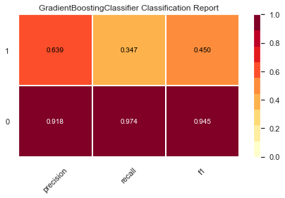

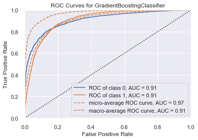

```python
#Fetching visuall Classification Report For our best GradientBoost Classifier -
visualClassifierReport(gbc3)
```

```
Training accuracy:  0.906310234777388

Testing accuracy:  0.90002948982601

Confusion Matrix
[[  555   313]
 [ 1043 11653]]
```

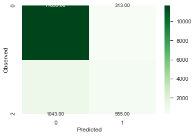

```
None

Recall:  0.34730913642052563

Precision:  0.6394009216589862

F1 Score:  0.45012165450121655

ROC_AUC Score:  0.660575845161625
```

```python
#fetch performance metrics
getModelPerformanceParams(ml_model_type, model_type_param,gbc3, prediction_GBC3)
```

```python
#Putting the best AdaBoost Classifier with n_estimator=50 into the final Results Table
trainDataScore,testDataScore,recall, precision, f1score, rocAucScore  = getFinalPerfParams(gbc3, prediction_GBC3)

tempfinalResultsDF = pd.DataFrame({'Method':[ml_model_type], 'Parameter':  model_type_param, 'Training score': trainDataScore, 'Accuracy': testDataScore, 'Recall': recall, 'Precision': precision, "F1_Score":f1score, "ROC_AUC Score":rocAucScore})
finalResultsDF = pd.concat([finalResultsDF, tempfinalResultsDF])
finalResultsDF
```

|  | Method | Parameter | Training score | Accuracy | Recall | Precision | F1_Score | ROC_AUC Score |
| --- | --- | --- | --- | --- | --- | --- | --- | --- |
| 0 | Logistic Regression | liblinear-penalty=l1 | 0.900654 | 0.898850 | 0.326658 | 0.638142 | 0.432119 | 0.650961 |
| 0 | Decision Tree | gini max_depth=5 | 0.906342 | 0.899219 | 0.333542 | 0.638323 | 0.438142 | 0.654152 |
| 0 | Bagging Classifier | estimators=50 | 0.993080 | 0.901209 | 0.451815 | 0.608769 | 0.518678 | 0.706519 |
| 0 | RandomForest Classifier | estimators=50 | 0.999779 | 0.902241 | 0.375469 | 0.646552 | 0.475059 | 0.674029 |
| 0 | AdaBoost Classifier | estimators=50 | 0.889784 | 0.888307 | 0.078223 | 0.748503 | 0.141643 | 0.537356 |
| 0 | GradientBoost Classifier | estimators=50 | 0.906310 | 0.900029 | 0.347309 | 0.639401 | 0.450122 | 0.660576 |

#### 3.3 Make a DataFrame to compare models and their metrics. Give conclusion regarding the best algorithm and your reason behind it. (5 marks)

```python
#Sorting the Final Ensemble Learning Algorithms for the Term Deposit prediciton Final Result DataFrame Based on ROC_AUC Score, Recall, F1_Score
finalResultsDF.sort_values(by='ROC_AUC Score', ascending=False).reset_index(drop=True)
```

|  | Method | Parameter | Training score | Accuracy | Recall | Precision | F1_Score | ROC_AUC Score |
| --- | --- | --- | --- | --- | --- | --- | --- | --- |
| 0 | Bagging Classifier | estimators=50 | 0.993080 | 0.901209 | 0.451815 | 0.608769 | 0.518678 | 0.706519 |
| 1 | RandomForest Classifier | estimators=50 | 0.999779 | 0.902241 | 0.375469 | 0.646552 | 0.475059 | 0.674029 |
| 2 | GradientBoost Classifier | estimators=50 | 0.906310 | 0.900029 | 0.347309 | 0.639401 | 0.450122 | 0.660576 |
| 3 | Decision Tree | gini max_depth=5 | 0.906342 | 0.899219 | 0.333542 | 0.638323 | 0.438142 | 0.654152 |
| 4 | Logistic Regression | liblinear-penalty=l1 | 0.900654 | 0.898850 | 0.326658 | 0.638142 | 0.432119 | 0.650961 |
| 5 | AdaBoost Classifier | estimators=50 | 0.889784 | 0.888307 | 0.078223 | 0.748503 | 0.141643 | 0.537356 |

### CONCLUSION: 1. FROM ML Models

#### AdaBoost Classifier performed most poorly.

#### For production purpose, I will increase the number of estimators on the Bagging Classifier until margin gains is seen on Recall, F1_Score and ROC_AUC Score, that is, till diminishing returns is seem - where increase in estimators does not necessarily lead to improvement in Recall, F1_Score and ROC_AUC Score. I will get the best estimators to use for production, in which I am sure am getting best predictions possible. Then focus on such customers for marketing of Term Deposits.

#### From Decision Tree, the following independent variables were identified as having strong influence on whether a customer will subscribe or not subscribe to Term Deposit, in descending order of importance:

1. duration
2. poutcome_success
3. age
4. pdays
5. contact
6. month
7. balance
8. housing loan subscription - preferrably, no is better
9. marital_married
10. whether customer has an admin job role.

### Finally, with the insights drawn both from the exploratory data analysis as well as the predictions from the Bagging Classifier, the bank is sure of improving subscription rate in its next campaign. In not missing out of customers with very high tendency to subscribe.